# Analyse a Simple Time Series

```r
library(pbsEDM)
```

This vignette shows how to use the simplex algorithm in `pbsEDM` to analyse a simple time series and forecast the next value, and shows resulting graphics that help understand the algorithm (as described in the manuscript). The tibble `NY_lags_example` is saved in the package and contains several columns, though we are only going to use the original time series of simulated population numbers, $N_t$, which has column name `N_t`. See `?NY_lags_example` for full details.

## Plot the data in different ways

We want to plot the data in different ways, for which it is easiest to first run the simplex algorithm (to create a `pbsEDM` object for which code automatically makes the figures).

Use only the `N_t` column from `NY_lags_example` and apply the simplex algorithm using lags of 0 and 1 ($E = 2$) with first differencing:

```r
E_2_res <- pbsEDM(NY_lags_example,
                  lags = list(N_t = c(0:1)),
                  first_difference = TRUE)
```

This creates a `pbsEDM` object which is a list of results (see `?pbsEDM` for full details):

```r
summary(E_2_res)
```

```
#>                    Length Class      Mode
#> N                    101  -none-     numeric
#> N_observed           101  -none-     numeric
#> N_forecast           101  -none-     numeric
#> Z                    100  -none-     numeric
#> Z_observed           100  -none-     numeric
#> Z_forecast           100  -none-     numeric
#> Y                    100  -none-     numeric
#> Y_observed           100  -none-     numeric
#> Y_forecast           100  -none-     numeric
#> X                    200  matrix     numeric
#> X_observed           100  -none-     numeric
#> X_forecast           100  -none-     numeric
#> X_distance         10000  matrix     numeric
#> neighbour_distance   300  -none-     numeric
#> neighbour_index      300  -none-     numeric
#> neighbour_value      300  -none-     numeric
#> neighbour_weight     300  -none-     numeric
#> projected_index      300  -none-     numeric
#> projected_value      300  -none-     numeric
#> projected_weight     300  -none-     numeric
#> lags                   1  -none-     list
#> p                      1  -none-     numeric
#> first_difference       1  -none-     logical
#> centre_and_scale       1  -none-     logical
#> exclusion_radius       1  -none-     character
#> results                5  data.frame list
```

For now we’ll just use that to plot the data in various useful ways:

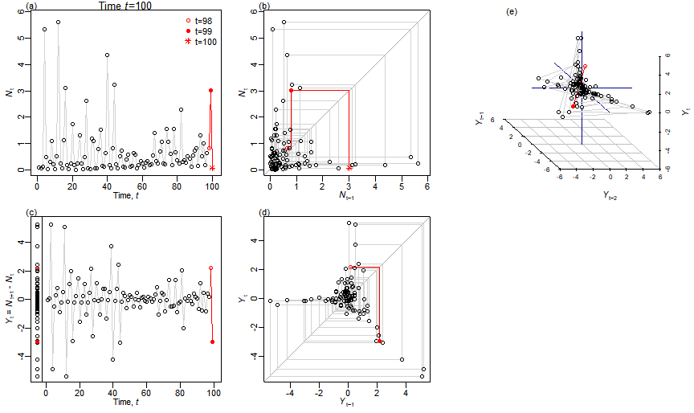

```r
plot(E_2_res,
     portrait = FALSE)
```

The figure shows, before using the results of the simplex algorithm, the data in various ways: time series of $N_t$ and $Y_t$, plus phase plots of $N_t$ vs $N_{t-1}$, $Y_t$ vs $Y_{t-1}$ (as used for $E=2$) and $Y_t$ vs $Y_{t-1}$ vs $Y_{t-2}$ (as used for $E=3$). The last 3 values of $N_t$ are in red, with the final one as a star. In the $Y_t$ time series panel, the values of $Y_t$ are also plotted in a vertical line (to the left of $t=0$) which is the one-dimensional equivalent of a phase plot for $E=1$.

An animated movie (with simplex results) is shown later below; to create the movie without the results use this code in an Rmarkdown document:

```r
{r, animation.hook = 'gifski', interval = 1.5, fig.width = 9, fig.height = 5.36}
## or for portrait use fig.width = 5.36, fig.height = 8
for(iiii in 1:length(NY_lags_example$N_t)){
  plot(E_2_res,
       last.time.to.plot = iiii,
       portrait = FALSE)
}
```

A lot of information is saved in the `E_2_res` list. See `?pbsEDM::pbsEDM` for full details, but, for example, useful summary statistics are given by

```r
E_2_res$results
```

```
#>   E     N_rho  N_rmse    X_rho  X_rmse
#> 1 2 0.2973217 1.12366 0.703475 1.12366
```

giving the embedding dimension $E$ (which is 2 here because we used lags of 0 and 1), forecast skill (correlation coefficient $\rho$) and root-mean-square error between the observations and the predictions.

## Make predictions using different values of E

Now use the simplex algorithm for different values of embedding dimension $E$, where, for example $E=2$ uses first-difference values $Y_t$ and $Y_{t-1}$:

```r
E_results <- pbsEDM_Evec(NY_lags_example$N_t)
```

The result is a list containing a `pbsEDM` object (as above) for each value of $E$, the default being values $E = 2, 3, ..., 11$:

```r
summary(E_results)
```

```
#>       Length Class  Mode
#>  [1,] 26     pbsEDM list
#>  [2,] 26     pbsEDM list
#>  [3,] 26     pbsEDM list
#>  [4,] 26     pbsEDM list
#>  [5,] 26     pbsEDM list
#>  [6,] 26     pbsEDM list
#>  [7,] 26     pbsEDM list
#>  [8,] 26     pbsEDM list
#>  [9,] 26     pbsEDM list
#> [10,] 26     pbsEDM list
```

There is a plotting function for the results, showing the data (as above) plus, in the final panel, the predicted value of each data point and the $\rho$ for each different value of $E$:

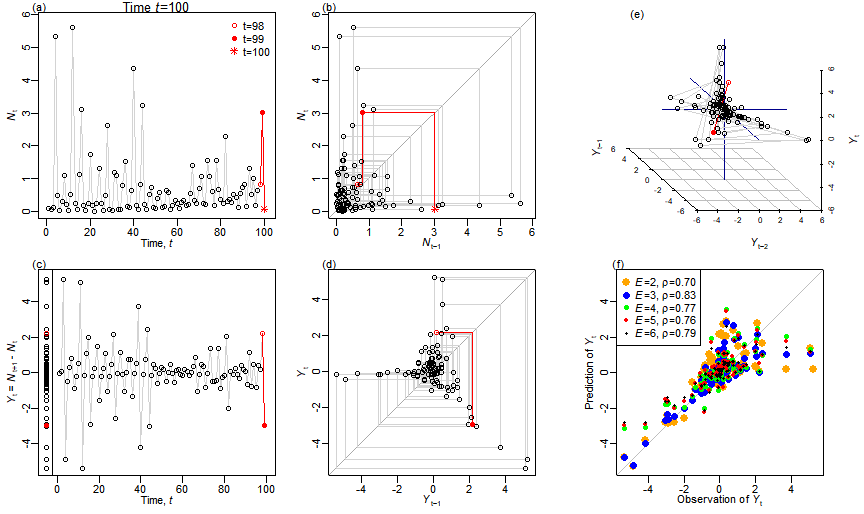

```r
plot_pbsEDM_Evec(E_results,
                 portrait = FALSE)
```

A movie of that is shown here:

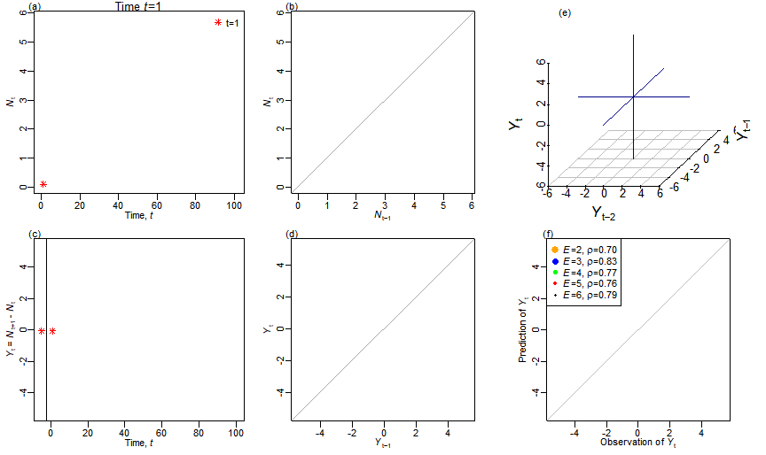

**Brief technical aside for full reproducibility**. That is a saved version to avoid R package building issues. To make the movie afresh, install the `gifski` package, delete the first line in the next chunk of code, uncomment the commented line and save the movie produced here directly from the html as `pbsEDM_movie_1.gif`; see the text above the movie on [this page](https://htmlpreview.github.io/?https://raw.githubusercontent.com/andrew-edwards/sizeSpectra/master/doc/MEPS_IBTS_recommend.html) if you want more details of this.

````r
# ```{r movietime, animation.hook = 'gifski', interval = 3, fig.width = 9, fig.height = 5.36}
for(iiii in 1:length(NY_lags_example$N_t)){
  plot_pbsEDM_Evec(E_results,
       last.time.to.plot = iiii,
       portrait = FALSE)
}
````

Now see how the forecast skill (correlation coefficient $\rho$) varies with $E$:

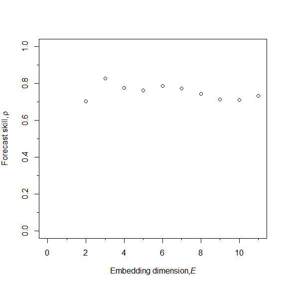

```r
plot_rho_Evec(E_results)
```

Each `E_results` component corresponds to a value of $E$, for example

```r
E_2_res$results
```

```
#>   E     N_rho  N_rmse    X_rho  X_rmse
#> 1 2 0.2973217 1.12366 0.703475 1.12366
```

```r
E_results[[1]]$results
```

```
#>   E     N_rho  N_rmse    X_rho  X_rmse
#> 1 2 0.2973217 1.12366 0.703475 1.12366
```

```r
E_results[[2]]$results
```

```
#>   E     N_rho    N_rmse     X_rho    X_rmse
#> 1 3 0.5363073 0.8122091 0.8280765 0.8122091
```

```r
E_results[[3]]$results
```

```
#>   E    N_rho    N_rmse     X_rho    X_rmse
#> 1 4 0.528308 0.8689543 0.7749746 0.8689543
```

The conclusion from the figure would be that $E = 3$ gives the highest value of $\rho$, and so is best used for forecasting $\hat{N}_{101}$. This is given by:

```r
E_results[[2]]$results           # [[2]] refers to E=3
```

```
#>   E     N_rho    N_rmse     X_rho    X_rmse
#> 1 3 0.5363073 0.8122091 0.8280765 0.8122091
```

```r
E_results[[2]]$Y_forecast[100]   # the forecast for Y_{100}
```

```
#> [1] -0.07706309
```

```r
E_results[[2]]$N_forecast[101]   # the forecast for N_{101}
```

```
#> [1] -0.01671682
```

In this case we obtain a negative forecast of $\hat{N}_{101}$ (which is explored as Aspect 3).

## Movie to demonstrate the simplex algorithm for $E=2$

Understanding of the simplex algorithm can be enhanced with a specific animated example. With $t^* = 39$ we have Figure S.2 from the manuscript:

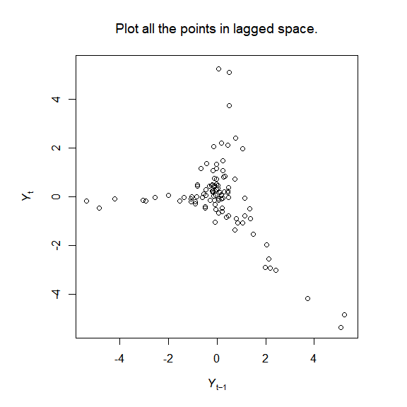

````r
# ```{r EDMmovie2, animation.hook = 'gifski', interval = 8}
plot_explain_edm_movie(E_2_res,
                       tstar = 39)
````

.

Such a movie is useful for checking any single prediction. For example, with $t^* = 15$ (see the technical aside above to make a new movie):

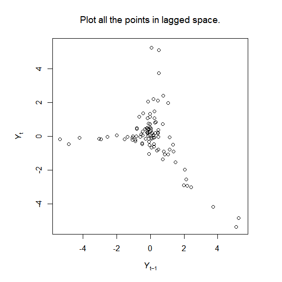

````r
# ```{r EDMmovie3, animation.hook = 'gifski', interval = 8}
plot_explain_edm_movie(E_2_res,
                       tstar = 15)
````

.

And changing to $t^* = 75$ shows the removal of an invalid candidate nearest neighbour from the library (right next to the blue solid circle) that would clearly have been used as a nearest neighbour if not removed:

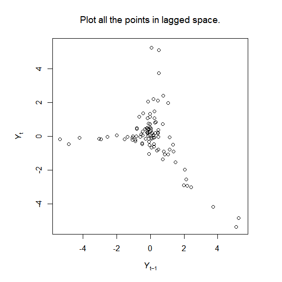

````r
# ```{r EDMmovie4, animation.hook = 'gifski', interval = 8}
plot_explain_edm_movie(E_2_res,
                       tstar = 75)
````

.

For the prediction of $Y_{100}$ we set $t^* = 99$ to give:

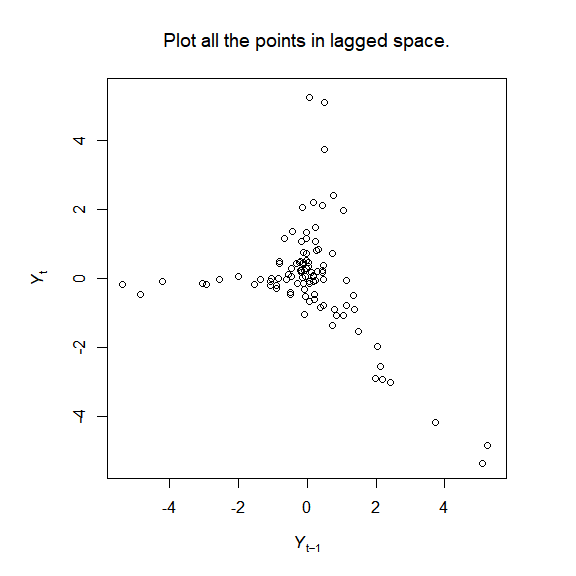

````r
# ```{r EDMmovie6, animation.hook = 'gifski', interval = 8}
plot_explain_edm_movie(E_2_res,
                       tstar = 99)
````

.

In this case there are no candidate nearest neighbours to cross out, because $t^* = T-1$ and all defined points are candidates. This can be seen in matrix (6) in the manuscript by setting $E=2$, $T=100$ and $t^* = 99$ (besides ${\bf x}_{t^*}$, only rows with a $\times$ get crossed out and since these are undefined they do not show up on the above plot anyway). Also there is no known true value of $Y_{100}$ in the final plot.

In the R console you can create a pdf version of any such movie with, for example:

```r
plot_explain_edm_movie_save(E_2_res,
                            pdf.filename = "movie_tstar_75.pdf",
                            tstar = 75)
```

## Further details of the calculations

The intermediate calculations of the simplex algorithm are saved in the output for perusal (see `?pbsEDM`). For example, to see the nearest neighbours for each valid $t^*$:

```r
E_2_res$neighbour_index
```

```
#>     [,1] [,2] [,3]
#> 1     NA   NA   NA
#> 2     64   61   85
#> 3     11   39   43
#> 4     12   40   44
#> 5     13   41   45
#> 6     57   88   53
#> 7     66   23   34
#> 8     67   24   95
#> 9     79   25   72
#> 10    26   46   69
#> 11     3   39   43
#> 12     4   40   44
#> 13     5   41   45
#> 14    30   73   42
```

[output cut: 86 more lines]